# Statistics workbook

### Problem 6.8.5

Two formulations of a certain coating, designed to inhibit corrosion, are being tested. For each of eight pipes, half the pipe is coated with formulation A and the other half is coated with formulation B. Each pipe is exposed to a salt environment for 500 hours. Afterward, the corrosion loss (in μm) is measured for each formulation on each pipe.

Can you conclude that the mean amount of corrosion differs between the two formulations?

D = $\bar{x_A} - \bar{x_B}$

$H_0$: $D = 0$

$H_1$: $D \neq 0$

```python
import pandas as pd
import numpy as np
from scipy.stats import ttest_rel

df = pd.read_csv("./datasets/Ch6/ex6-8-5.csv")
t, p = ttest_rel(df["A"], df["B"])

print(f'p-value: {p}')
print(f't: {t}')
```

```
p-value: 0.01934828466050993
t: -3.021390645237225
```

We reject $H_0$ since p-value is less than 0.05. Thus we can conclude that the mean corrosion differs between the formulations.

### Problem 6.8.10

A group of eight individuals with high cholesterol levels were given a new drug that was designed to lower cholesterol levels. Cholesterol levels, in mg/dL, were measured before and after treatment for each individual, with the following results:

a. Can you conclude that the mean cholesterol level after treatment is less than the mean before treatment?

D = $\bar{x_a} - \bar{x_b}$

$H_0: D \geq 0$

$H_1: D \lt 0$

```python
import pandas as pd
import numpy as np
from scipy.stats import ttest_rel

df = pd.read_csv("./datasets/Ch6/ex6-8-10.csv")

t, p = ttest_rel(df["After"], df["Before"], alternative="less", )


print(f'p-value: {p}')
print(f't: {t}')
```

```
p-value: 3.2732685392738495e-07
t: -16.7745404068734
```

So we reject $H_0$ because the p-value is < 0.05. Thus we can conclude that the mean cholesterol level after a treament is less than before it.

b. Can you conclude that the reduction in mean cholesterol level after treatment is greater than 75 mg/dL?

D = $\bar{x_b} - \bar{x_a} $

$H_0: D \lt 75$

$H_1: D \geq 75$

```python
import pandas as pd
import numpy as np
from scipy.stats import ttest_ind

df = pd.read_csv("./datasets/Ch6/ex6-8-10.csv")

difference = df["Before"] - df["After"]

D = [75 for i in range(len(difference))]

t, p = ttest_ind(difference, D, equal_var=False, alternative="greater")


print(f'p-value: {p}')
print(f't: {t}')
```

```
p-value: 0.19297378266765725
t: 0.9245809673079826
```

### Problem 6.10.2

Can you conclude that the quality varies among shifts?

a) State the appropriate null hypothesis.

$D = 0$

$H_0: D = 0$, there is no difference of quality between shifts.

$H_1; D \neq 0$, there quality varies between shifts.

Let's use a chi-squared test of homogenity

b) Compute the expected values under the null hypothesis.

c) Compute the value of the chi-square statistic.

d) Find the P-value. What do you conclude?

```python
import pandas as pd
from scipy.stats import chi2_contingency

df = pd.read_csv("datasets/Ch6/ex6-10-2.csv")

info = chi2_contingency(df[["High Quality", "Moderate Quality","Low Quality"]])

chi_stat = info[0]
p_val = info[1]


print("Expected Matrix:")
print(info[3])
print(f'\nchi-square statistic: {chi_stat}')
print(f'p-value: {p_val}')
```

```
Expected Matrix:
[[466.4        196.4         37.2       ]
 [433.08571429 182.37142857  34.54285714]
 [266.51428571 112.22857143  21.25714286]]

chi-square statistic: 5.76044648212817
p-value: 0.21776679146359837
```

Since the p-value > 0.05 we accept $H_0$ and thus conclude that the quality doesn't vary between shifts

### Problem 6.10.3

Each respondent was categorized by gender and income level. The numbers in each category (calculated from percentages given in the article) are presented in the following table. Can you conclude that the proportions in the various income categories differ between men and women?

$H_0:$ The proportions in the various income categories doesn't differ between men and women (D = 0)

$H_1:$ The proporiton in the various income coatgories differ between men and women ($D \neq 0$)

```python
import pandas as pd
from scipy.stats import chi2_contingency

df = pd.read_csv("datasets/Ch6/ex6-10-3.csv")

results = chi2_contingency(df.drop(columns="Unnamed: 0"))

p_val = results[1]

print(f'p-value: {p_val}')
```

```
p-value: 1.6334870030348423e-22
```

We reject $H_0$ since p < 0.05 is significantly lower. It differs between men and women.

### Problem 6.10.4

The article “Analysis of Time Headways on Urban Roads: Case Study from Riyadh” (A. Al-Ghamdi, Journal of Transportation Engineering, 2001:289–294) presents a model for the time elapsed between the arrival of consecutive vehicles on urban roads. Following are 137 arrival times (in seconds) along with the values expected from a theoretical model.

Can you conclude that the theoretical model does not explain the observed values well?

$H_0:$ the theoretical model does explain thte observed values

$H_1:$ the theoretical model doesn't explain thte observed values

```python
import pandas as pd
from scipy.stats import chisquare

df = pd.read_csv("datasets/Ch6/ex6-10-4.csv")


x, p = chisquare(df['Observed'], df['Expected'])
print(x)
print(f'p-value: {p}')
df
```

```
21.47460834360148
p-value: 0.005988018189390258
```

|  | Time | Observed | Expected |
| --- | --- | --- | --- |
| 0 | 0 to 2 | 18 | 23 |
| 1 | 2 to 4 | 28 | 18 |
| 2 | 4 to 6 | 14 | 16 |
| 3 | 6 to 8 | 7 | 13 |
| 4 | 8 to 10 | 11 | 11 |
| 5 | 10 to 12 | 11 | 9 |
| 6 | 12 to 18 | 10 | 20 |
| 7 | 18 to 22 | 8 | 8 |
| 8 | >22 | 30 | 19 |

Since the p value is significantly < 0.05 we reject $H_0$, and conclude the theoretical model doesn't explain the data.

### Problem 6.10.12

Following are the numbers of workers reporting various symptoms, categorized by work shift. The numbers were read from a graph.

Can you conclude that the proportions of workers with the various symptoms differ among the shifts?

$H_0:$ the symptoms do not differ between shifts (D = 0)

$H_1:$ the symptoms do not differ between shifts ($D \neq 0$)

```python
import pandas as pd
from scipy.stats import chi2_contingency

df = pd.read_csv("datasets/Ch6/ex6-10-12.csv")

results = chi2_contingency(df.drop(columns="Unnamed: 0"))

p_value = results[1]

print(f'p-value:{p_value}')
```

```
p-value:0.007397040450634263
```

Since the p-value is significantly lower than < 0.05 we reject $H_0$ and thus conclude that the symptoms differ between shifts.

### Problem 7.1.1

Compute the correlation coefficient for the following data set.

```python
import pandas as pd
from scipy.stats import pearsonr

df = pd.read_csv("datasets/Ch7/ex7-1-1.csv")
print(df)

r, p = pearsonr(df['x'], df['y'])

print()
print(f'Correlation coefficient: {r}')
print(f'p-value: {p}')
```

```
   x  y
0  1  2
1  2  1
2  3  4
3  4  3
4  5  7
5  6  5
6  7  6

Correlation coefficient: 0.8214285714285715
p-value: 0.023448808345691494
```

### Problem 7.1.2

Since the correlation coefficient is unitless it remains unchanged when:

- Multiplying each value of a variable by a positive constant.
- Adding a constant to each value of a variable.
- Interchanging the values of x and y.

Need explaining (?)

```
0.3352119050341078
```

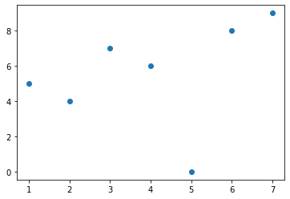

```python
import pandas as pd
from scipy.stats import pearsonr
import matplotlib.pyplot as plt

df = pd.read_csv("datasets/Ch7/ex7-1-2a.csv")

r, p = pearsonr(df['x'], df['y'])

print(r)

plt.scatter(df['x'], df['y'])
```

### Problem 7.1.6

In a study of ground motion caused by earthquakes, the peak velocity (in m/s) and peak acceleration (in m/s2) were recorded for five earthquakes. The results are presented in the following table.

a) Compute the correlation coefficient between peak velocity and peak acceleration.

b) Construct a scatterplot for these data.

c) Is the correlation coefficient an appropriate summary for these data? Explain why or why not.

d) Someone suggests converting the units from meters to centimeters and from seconds to minutes. What effect would this have on the correlation?

```
a) Correlation coefficient: -0.8027544804065294
b) p-value: 0.10199023144451251
c) No since the p > 0.05, so they are not correlated
d) No, it has no effect on the correlation coefficient
```

|  | Velocity | Acceleration |
| --- | --- | --- |
| 0 | 1.54 | 7.64 |
| 1 | 1.60 | 8.04 |
| 2 | 0.95 | 8.04 |
| 3 | 1.30 | 6.37 |
| 4 | 2.92 | 5.00 |

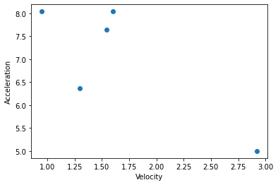

```python
import pandas as pd
import numpy as np
from scipy.stats import pearsonr
import matplotlib.pyplot as plt

df = pd.read_csv("datasets/Ch7/ex7-1-6.csv")

r, p = pearsonr(df['Velocity'], df['Acceleration'])

print(f'a) Correlation coefficient: {r}')
print(f'b) p-value: {p}')
print(f'c) No since the p > 0.05, so they are not correlated')
print(f'd) No, it has no effect on the correlation coefficient')
plt.scatter(df['Velocity'], df['Acceleration'],)
plt.xlabel("Velocity")
plt.ylabel("Acceleration")

df
```

### Problem 7.1.9

A blood pressure measurement consists of two numbers: the systolic pressure, which is the maximum pressure taken when the heart is contracting, and the diastolic pressure, which is the minimum pressure taken at the beginning of the heartbeat. Blood pressures were measured, in millimeters of mercury (mmHg), for a sample of 14 adults. The following table presents the results. Assume that blood pressures follow a bivariate normal distribution.

a) Find a 95% confidence interval for ρ, the correlation between systolic and diastolic blood pressure.

c) Can you conclude that $\rho$ > 0?

```python
import pandas as pd
import scipy
from scipy.stats import pearsonr, norm
import numpy as np

def pearsonr_ci(x,y,alpha=0.05):
    #see documentation https://zhiyzuo.github.io/Pearson-Correlation-CI-in-Python/
    r, p = pearsonr(x,y)
    r_z = np.arctanh(r)
    se = 1/np.sqrt(x.size-3)
    z = norm.ppf(1-alpha/2)
    lo_z, hi_z = r_z-z*se, r_z+z*se
    lo, hi = np.tanh((lo_z, hi_z))
    return r, p, lo, hi

df = pd.read_csv("datasets/Ch7/ex7-1-9.csv")
r, p, lo, hi = pearsonr_ci(df['Systolic'], df['Diastolic'])
r, p = pearsonr(df['Systolic'], df['Diastolic'], alternative="greater")

print(f'95% CI for rho: [{lo}, {hi}]')
print(f'p-value: {p}')
```

```
95% CI for rho: [0.2508320831610047, 0.8933354657851348]
p-value: 0.0031766963781086764
```

Yes since the confidence interval is > 0 we can conclude that the correlation coefficent is > 0

### Problem 7.2.11

Structural engineers use wireless sensor networks to monitor the condition of dams and bridges. The article “Statistical Analysis of Vibration Modes of a Suspension Bridge Using Spatially Dense Wireless Sensor Network” (S. Pakzad and G. Fenves, Journal of Structural Engineering, 2009:863–872) describes an experiment in which accelerometers were placed on the Golden Gate Bridge for the purpose of estimating vibration modes. For 18 vertical modes, the system was underdamped (damping ratio < 1). Following are the damping ratios and frequencies for those modes.

a) Construct a scatterplot of frequency (y) versus damping ratio (x). Verify that a linear model is appropriate.

b) Compute the least-squares line for predicting frequency from damping ratio.

c) If two modes differ in damping ratio by 0.2, by how much would you predict their frequencies to differ?

d) Predict the frequency for modes with damping ratio 0.75.

e) Should the equation be used to predict the frequency for modes that are overdamped (damping ratio > 1)? Explain why or why not.

f) For what damping ratio would you predict a frequency of 2.0?

```
a) As we can see from the graph a linear model is appropriate
b) Freq: y = 4.3416 + -4.9051x
c) diffrence in freq: 0.981
d) Freq for modes 0.75: 0.6627
e) No since, all the modes in the data set ar less than 1, it would be illogical to use this dataset to try to predict damping over 1
f) Predicted damping ration for freq 2: 0.4774
```

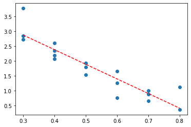

```python
import pandas as pd
import numpy as np
import matplotlib.pyplot as plt
from scipy.stats import linregress

df = pd.read_csv("datasets/Ch7/ex7-2-11.csv")

x = df["Damping Ratio"]
y = df["Frequency"]

reg = linregress(x,y)

slope = reg.slope
intercept = reg.intercept
p_val = reg.pvalue

best_line = lambda x: intercept + slope * x
inverse_best_line = lambda y: (y - intercept) / slope

answer_a = f'As we can see from the graph a linear model is appropriate'
answer_b = f'y = {round(intercept,4)} + {round(slope,4)}x'
answer_c = round(best_line(0.2) - best_line(0.4), 4)
answer_d = round(best_line(0.75),4)
answer_e = f'No since, all the modes in the data set ar less than 1, it would be illogical to use this dataset to try to predict damping over 1'
answer_f = round(inverse_best_line(2),4)

print(f'a) {answer_a}')
print(f'b) Freq: {answer_b}')
print(f'c) diffrence in freq: {answer_c}')
print(f'd) Freq for modes 0.75: {answer_d}')
print(f'e) {answer_e}')
print(f'f) Predicted damping ration for freq 2: {answer_f}')

plt.scatter(x,y)
plt.plot(x, slope * x + intercept, color="red", linestyle="--")
```

### Problem 7.2.12

The article “Effect of Environmental Factors on Steel Plate Corrosion Under Marine Immersion Conditions” (C. Soares, Y. Garbatov, and A. Zayed, Corrosion Engineering, Science and Technology, 2011:524–541) describes an experiment in which nine steel specimens were submerged in seawater at various temperatures, and the corrosion rates were measured. The results are presented in the following table (obtained by digitizing a graph).

a) Construct a scatterplot of corrosion (y) versus temperature (x). Verify that a linear model is appropriate.

b) Compute the least-squares line for predicting corrosion from temperature.

c) Two steel specimens whose temperatures differ by 10°C are submerged in seawater. By how much would you predict their corrosion rates to differ?

d) Predict the corrosion rate for steel submerged in seawater at a temperature of 20°C.

e) Compute the fitted values.

f) Compute the residuals. Which point has the residual with the largest magnitude?

g) Compute the correlation between temperature and corrosion rate.

h) Compute the regression sum of squares, the error sum of squares, and the total sum of squares.

i) Divide the regression sum of squares by the total sum of squares. What is the relationship between this quantity and the correlation coefficient?

```
a) yes as we can see from the scatter a linear model is appropriate
b) 0.394 + 0.0355x
c) 0.3551
d) 1.1041
e) [1.3385, 1.3172, 1.3669, 1.1645, 0.923, 0.7952, 0.9266, 0.7029, 0.6851]
f)
0    0.2415
1    0.1328
2   -0.2369
3   -0.2045
4    0.0670
5    0.2548
6   -0.1066
7   -0.0229
8   -0.1251
Name: Corrosion, dtype: float64
max residual: index 5
g) 0.8326
h)
ESS: 0.2708
RSS: 0.6122
TSS: 0.883
i) RSS/TSS = correlation coefficient^2 = 0.6933 = 0.6933
```

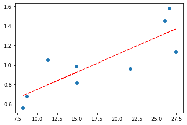

```python
import pandas as pd
import numpy as np
import matplotlib.pyplot as plt
from scipy.stats import linregress

df = pd.read_csv("datasets/Ch7/ex7-2-12.csv")
df

x = df["Temperature"]
y = df["Corrosion"]
y_bar = y.mean()

reg = linregress(x,y)
slope = reg.slope
intercept = reg.intercept

best_line = lambda x: intercept + slope * x
fitted_values = []

for x_i in x:
    y_hat = intercept + slope * x_i
    fitted_values.append(round(y_hat,4))


residuals = y - fitted_values
max_res = abs(residuals).argmax()

ess = ((fitted_values - y)**2).sum()
rss = sum([(y - y_bar)**2 for y in fitted_values])
tss = ess + rss
r_2 = rss / tss

answer_a = f'a) yes as we can see from the scatter a linear model is appropriate'
answer_b = f'b) {round(intercept,4)} + {round(slope, 4)}x'
answer_c = f'c) {round(best_line(20) - best_line(10),4)}'
answer_d = f'd) {round(best_line(20),4)}'
answer_e = f'e) {fitted_values}'
answer_f = f'f)\n{residuals}\nmax residual: index {max_res}'
answer_g = f'g) {round(reg.rvalue,4)}'
answer_h = f'h)\nESS: {round(ess,4)}\nRSS: {round(rss,4)}\nTSS: {round(tss,4)}'
answer_i = f'i) RSS/TSS = correlation coefficient^2 = {round(rss / tss,4)} = {round(reg.rvalue**2,4)}'

print(answer_a)
print(answer_b)
print(answer_c)
print(answer_d)
print(answer_e)
print(answer_f)
print(answer_g)
print(answer_h)
print(answer_i)

plt.scatter(x,y)
plt.plot(x, intercept + slope * x, color="red", linestyle="--")
```

### Problem 7.3.9

a) Compute the least-squares line for predicting evaporation (y) from temperature (x).

b) Compute 95% confidence intervals for $\beta_0$ and $\beta_1$.

c) Predict the evaporation rate when the temperature is 20°C.

```python
import pandas as pd
import numpy as np
import matplotlib.pyplot as plt
from scipy.stats import linregress, t

df = pd.read_csv("datasets/Ch7/ex7-3-9.csv")

x = df["Temp"]
y = df["Evap"]

reg = linregress(x,y)

slope = reg.slope
intercept = reg.intercept

best_line = lambda x: intercept + slope * x

a = t.ppf(0.975, x.size - 2)

ci_beta_0 = f'[{round(intercept - a * reg.intercept_stderr,4)},{round(intercept + a * reg.intercept_stderr,4)}]'
ci_beta_1 = f'[{round(slope - a * reg.stderr,4)},{round(slope + a * reg.stderr,4)}]'

answer_c = round(best_line(20),4)

print(f'a) y = {round(intercept,4)} + {round(slope, 4)}x')
print(f'b)\n95% CI beta_0: {ci_beta_0}\n95% CI beta_1: {ci_beta_1}')
print(f'c) {answer_c}')
```

```
a) y = -0.3258 + 0.2234x
b)
95% CI beta_0: [-2.0308,1.3791]
95% CI beta_1: [0.1464,0.3005]
c) 4.1431
```

### Problem 7.4.9

The National Assessment for Educational Progress measured the percentage of eighth grade students who were proficient in reading and the percentage of students who graduated from high school in each state in the U.S. The results for the ten most populous states are as follows:

a) Construct a scatterplot of graduation rate (y) versus reading proficiency (x). Which state is an outlier?

b) Compute the least-squares line for predicting graduation rate from reading proficiency, using the data from all ten states.

c) Remove the outlier and compute the least-squares line, using the data from the other nine states.

d) Is the outlier an influential point? Explain.

```
a) California is an outlier
b) y = 30.1218 + 0.5958x
c) y = -22.7145 + 1.3046x
d)
p-value with outlier: 0.1307
p-value without outlier: 0.0076
As we can see from the p-values the outliers is really influential on the dataset, with the outlier the correlation is rejected and attributed to randomness, but without it we see that the data produces as significant trend.
```

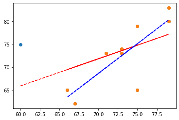

```python
import pandas as pd
import numpy as np
import matplotlib.pyplot as plt
from scipy.stats import linregress

df = pd.read_csv("datasets/Ch7/ex7-4-9.csv")

df2 = df.loc[1:9]


x = df["Reading Proficiency"]
y = df["Graduation Rate"]

x2 = df2["Reading Proficiency"]
y2 = df2["Graduation Rate"]

reg_10 = linregress(x,y)
slope_10 = reg_10.slope
intercept_10 = reg_10.intercept
p_10 = reg_10.pvalue

reg_9 = linregress(x2,y2)
slope_9 = reg_9.slope
intercept_9 = reg_9.intercept
p_9 = reg_9.pvalue

answer_a = f'a) California is an outlier'
answer_b = f'b) y = {round(intercept_10,4)} + {round(slope_10, 4)}x'
answer_c = f'c) y = {round(intercept_9,4)} + {round(slope_9, 4)}x'

print(answer_a)
print(answer_b)
print(answer_c)
print('d)')
print(f'p-value with outlier: {round(p_10,4)}')
print(f'p-value without outlier: {round(p_9,4)}')
print(f'As we can see from the p-values the outliers is really influential on the dataset, with the outlier the correlation is rejected and attributed to randomness, but without it we see that the data produces as significant trend.')

plt.scatter(x,y)
plt.plot(x, intercept_10 + slope_10 * x, color="red", linestyle="--")

plt.scatter(x2,y2)
plt.plot(x2, intercept_9 + slope_9 * x2, color="blue", linestyle="--")
```

### Fisher 2x2 contingency test

```python
import numpy as np
import pandas as pd
from scipy.stats import fisher_exact

data = np.array([[17, 9], [16, 22]])

df = pd.DataFrame(data, index=['admitted', 'rejected'], columns=['girls', 'boys'])

odds_rat, p = fisher_exact(df)
print(odds_rat)
print(p)
df
```

```
2.5972222222222223
0.08003496009127051
```

|  | girls | boys |
| --- | --- | --- |
| admitted | 17 | 9 |
| rejected | 16 | 22 |

Since the p-value is above 0.05 we accept $H_0$ and conclude that there is not a gender bias.

### Simple linear regression

a)

```
LinregressResult(slope=0.20462406015037599, intercept=4.999714285714285, rvalue=0.9743193083175269, pvalue=4.2037584649203017e-13, stderr=0.011146311882917918, intercept_stderr=0.02477391625966531)
```

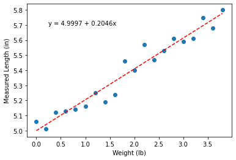

```python
import pandas as pd
import numpy as np
import matplotlib.pylab as plt
from scipy.stats import linregress


df = pd.read_csv("datasets/Ch7/table7-1.csv")

x = df['Weight (x)']
y = df['Measured Length (y)']

reg = linregress(x, y)
print(reg)
slope = reg[0]
intercept = reg[1]

plt.scatter(x, y)
plt.plot(x, slope * x + intercept, color='red',linestyle='--')


plt.xlabel('Weight (lb)')
plt.ylabel('Measured Length (in)')

best_line = f'y = {round(intercept,4)} + {round(slope,4)}x'

plt.text(0.25, 5.7, best_line)
```

b)

```
LinregressResult(slope=0.11684917103910851, intercept=12.699274285714289, rvalue=0.9743193083175268, pvalue=4.203758464920466e-13, stderr=0.006365025220910872, intercept_stderr=0.06292574729954999)
```

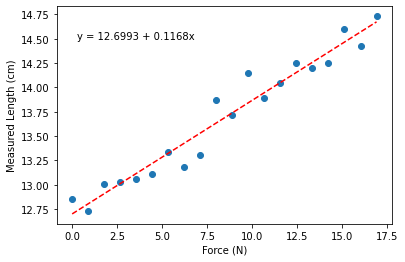

```python
import pandas as pd
import numpy as np
import matplotlib.pylab as plt
from scipy.stats import linregress


df = pd.read_csv("datasets/Ch7/table7-1.csv")


x = df['Weight (x)'] * 4.448
y = df['Measured Length (y)'] * 2.54

reg = linregress(x, y)
print(reg)
slope = reg[0]
intercept = reg[1]

plt.scatter(x, y)
plt.plot(x, slope * x + intercept, color='red',linestyle='--')


plt.xlabel('Force (N)')
plt.ylabel('Measured Length (cm)')

best_line = f'y = {round(intercept,4)} + {round(slope,4)}x'

plt.text(0.25, 14.5, best_line)
```

c)

```python
import pandas as pd
import numpy as np

df = pd.read_csv("datasets/Ch7/table7-1.csv")

x = df['Weight (x)'] * 4.448
y = df['Measured Length (y)'] * 2.54

xy = x * y
x_2 = x * x

xy_bar = xy.mean()
x_2_bar = x_2.mean()

x_bar = x.mean()
y_bar = y.mean()

slope = (xy_bar - x_bar * y_bar) / (x_2_bar  - x_bar**2)

intercept = y_bar - slope * x_bar

print(f'{round(intercept,4)} + {round(slope,4)}x')
```

```
12.6993 + 0.1168x
```

Which is the same as the calculations made by the software so the math checks out.

d)

```python
import pandas as pd
import numpy as np
import matplotlib.pylab as plt
from scipy.stats import linregress, t


df = pd.read_csv("datasets/Ch7/table7-1.csv")


x = df['Weight (x)'] * 4.448
y = df['Measured Length (y)'] * 2.54

reg = linregress(x,y)

slope = reg.slope
intercept = reg.intercept
stderr = reg.stderr
int_stderr = reg.intercept_stderr

#print(t.ppf(0.025, len(x) - 2))
a = t.ppf(0.975, len(x) - 2)


print(f'95% CI for slope: [{round(slope - a * stderr,4)},{round(slope + a * stderr, 4)}]')
print(f'95% CI for intercept: [{round(intercept - a * int_stderr,4)},{round(intercept + a * int_stderr,4)}]')
```

```
95% CI for slope: [0.1035,0.1302]
95% CI for intercept: [12.5671,12.8315]
```

e)

```python
import pandas as pd
import numpy as np
import matplotlib.pylab as plt
from scipy.stats import linregress


df = pd.read_csv("datasets/Ch7/table7-1.csv")

x = df['Weight (x)'] * 4.448
y = df['Measured Length (y)'] * 2.54

reg_new = linregress(y, x)
reg_old = linregress(x, y)

r_val = reg_new.rvalue

new_slope = reg_new.slope
old_slope = reg_old.slope

new_intercept = reg_new.intercept
old_intercept = reg_old.intercept

r_calc = new_slope * old_slope
print(r_calc)
print(r_val**2)
print(f'{r_calc} = {r_val**2} = R^2')
```

```
0.9492981145603439
0.9492981145603439
0.9492981145603439 = 0.9492981145603439 = R^2
```

## Miniprojects

### Miniproject 1 (week 5)

Step 1:

$0 \leq x \leq 1$

$\mu = \frac{1 - 0}{2} = \frac{1}{2}$

$\sigma^2 = \frac{(1 - 0)^2}{12} \\ \sigma = \sqrt{\frac{1}{12}} = \frac{1}{2\sqrt{3}}$

```python
from numpy import random, mean, std
import pandas as pd

k = 10
n = 10
m = []
stddevs = []
df = pd.DataFrame()

for i in range(k):
    rand_lis =  [random.random_sample(1) for _ in range(n)]
    m.append(mean(rand_lis))
    stddevs.append(std(rand_lis))

df['M'] = m
df['Std.dev'] = stddevs
#df = df.set_axis([f'S{i}' for i in range(1,k)])
```

```python
mean_mean = df['M'].mean()
print(f'n: {n}\nk: {k}')
print(f'Mean of the mean: {round(mean_mean,5)}')
sample_std_of_m = df['M'].std()
mean_of_std = df['Std.dev'].mean()
print(f'Mean of stddev: {round(mean_of_std,5)}\nStddev: {round(1 / sqrt(12),5)}\nSample std of m: {round(sample_std_of_m,7)}\nTrue sample std: {round(1 / sqrt(12 * n),7)}')
print('As we can observe the mean of the mean is much closer to the true mean (0.5) than in array M')
```

```
n: 10
k: 10
Mean of the mean: 0.52888
Mean of stddev: 0.26991
Stddev: 0.28868
Sample std of m: 0.0853235
True sample std: 0.0912871
As we can observe the mean of the mean is much closer to the true mean (0.5) than in array M
```

n: 10

k: 10

Mean of the mean: 0.46781

Mean of stddev: 0.25057

Stddev: 0.28868

Sample std of m: 0.0840819

True sample std: 0.0912871

n: 100

k: 10

Mean of the mean: 0.49524

Mean of stddev: 0.28404

Stddev: 0.28868

Sample std of m: 0.0339839

True sample std: 0.0288675

n: 1000

k: 10

Mean of the mean: 0.50005

Mean of stddev: 0.28852

Stddev: 0.28868

Sample std of m: 0.0070751

True sample std: 0.0091287

n: 10000

k: 10

Mean of the mean: 0.50059

Mean of stddev: 0.28877

Stddev: 0.28868

Sample std of m: 0.0021885

True sample std: 0.0028868

n: 100000

k: 10

Mean of the mean: 0.49977

Mean of stddev: 0.28855

Stddev: 0.28868

Sample std of m: 0.0013092

True sample std: 0.0009129

n: 1000000

k: 10

Mean of the mean: 0.49999

Mean of stddev: 0.28866

Stddev: 0.28868

Sample std of m: 0.0002473

True sample std: 0.0002887

n: 10

k: 100

Mean of the mean: 0.48305

Mean of stddev: 0.26485

Stddev: 0.28868

Sample std of m: 0.0944039

True sample std: 0.0912871

n: 10

k: 1000

Mean of the mean: 0.49714

Mean of stddev: 0.2687

Stddev: 0.28868

Sample std of m: 0.0856888

True sample std: 0.0912871

n: 10

k: 10000

Mean of the mean: 0.499

Mean of stddev: 0.26983

Stddev: 0.28868

Sample std of m: 0.0910039

True sample std: 0.0912871

n: 10

k: 100000

Mean of the mean: 0.49967

Mean of stddev: 0.27023

Stddev: 0.28868

Sample std of m: 0.0911934

True sample std: 0.0912871

### Miniproject phase 2 (week 6)

The mean value of the numbers in sample M is expected close to 0.5. But now let’s focus on their distribution, which is the normal distribution. Consider now samples S of a fixed size n=10. Generate k samples of type M. Use k = 10, 100, ..., 1000000. (Excel users should try as much as they can.) For each k make a histogram of M with a constant number of bins, say 20-30.

```
n: 10
k: 10
Mean of the mean: 0.46743
Mean of stddev: 0.27881
Stddev: 0.28868
Sample std of m: 0.079361
True sample std: 0.0912871
As we can observe the mean of the mean is much closer to the true mean (0.5) than in array M
```

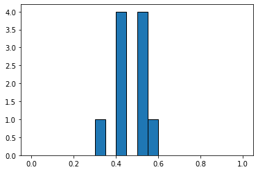

```python
from numpy import random, mean, std
import pandas as pd
import matplotlib.pyplot as plt

k = 10
n = 10
m = []
stddevs = []
df = pd.DataFrame()

bins = [0, 0.05,0.1,0.15,0.2,0.25,0.3,0.35,0.40,0.45,0.50,0.55,0.60,0.65,0.70,0.75,0.80,0.85,0.90,0.95,1]

for i in range(k):
    rand_lis =  [random.random_sample(1) for _ in range(n)]
    m.append(mean(rand_lis))
    stddevs.append(std(rand_lis))

df['M'] = m
df['Std.dev'] = stddevs

mean_mean = df['M'].mean()
print(f'n: {n}\nk: {k}')
print(f'Mean of the mean: {round(mean_mean,5)}')
sample_std_of_m = df['M'].std()
mean_of_std = df['Std.dev'].mean()
print(f'Mean of stddev: {round(mean_of_std,5)}\nStddev: {round(1 / sqrt(12),5)}\nSample std of m: {round(sample_std_of_m,7)}\nTrue sample std: {round(1 / sqrt(12 * n),7)}')
print('As we can observe the mean of the mean is much closer to the true mean (0.5) than in array M')

plt.hist(df['M'], bins=bins, edgecolor='k')
```

```
n: 10
k: 100
Mean of the mean: 0.51007
Mean of stddev: 0.26834
Stddev: 0.28868
Sample std of m: 0.094961
True sample std: 0.0912871
As we can observe the mean of the mean is much closer to the true mean (0.5) than in array M
```

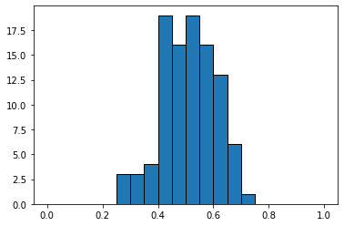

```python
k = 100
n = 10
m = []
stddevs = []
df = pd.DataFrame()

bins = [0, 0.05,0.1,0.15,0.2,0.25,0.3,0.35,0.40,0.45,0.50,0.55,0.60,0.65,0.70,0.75,0.80,0.85,0.90,0.95,1]

for i in range(k):
    rand_lis =  [random.random_sample(1) for _ in range(n)]
    m.append(mean(rand_lis))
    stddevs.append(std(rand_lis))

df['M'] = m
df['Std.dev'] = stddevs

mean_mean = df['M'].mean()
print(f'n: {n}\nk: {k}')
print(f'Mean of the mean: {round(mean_mean,5)}')
sample_std_of_m = df['M'].std()
mean_of_std = df['Std.dev'].mean()
print(f'Mean of stddev: {round(mean_of_std,5)}\nStddev: {round(1 / sqrt(12),5)}\nSample std of m: {round(sample_std_of_m,7)}\nTrue sample std: {round(1 / sqrt(12 * n),7)}')
print('As we can observe the mean of the mean is much closer to the true mean (0.5) than in array M')

plt.hist(df['M'], bins=bins, edgecolor='k')
```

```
n: 10
k: 1000
Mean of the mean: 0.49954
Mean of stddev: 0.27109
Stddev: 0.28868
Sample std of m: 0.0924666
True sample std: 0.0912871
As we can observe the mean of the mean is much closer to the true mean (0.5) than in array M
```

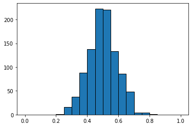

```python
k = 1000
n = 10
m = []
stddevs = []
df = pd.DataFrame()

bins = [0, 0.05,0.1,0.15,0.2,0.25,0.3,0.35,0.40,0.45,0.50,0.55,0.60,0.65,0.70,0.75,0.80,0.85,0.90,0.95,1]

for i in range(k):
    rand_lis =  [random.random_sample(1) for _ in range(n)]
    m.append(mean(rand_lis))
    stddevs.append(std(rand_lis))

df['M'] = m
df['Std.dev'] = stddevs

mean_mean = df['M'].mean()
print(f'n: {n}\nk: {k}')
print(f'Mean of the mean: {round(mean_mean,5)}')
sample_std_of_m = df['M'].std()
mean_of_std = df['Std.dev'].mean()
print(f'Mean of stddev: {round(mean_of_std,5)}\nStddev: {round(1 / sqrt(12),5)}\nSample std of m: {round(sample_std_of_m,7)}\nTrue sample std: {round(1 / sqrt(12 * n),7)}')
print('As we can observe the mean of the mean is much closer to the true mean (0.5) than in array M')

plt.hist(df['M'], bins=bins, edgecolor='k')
```

```
n: 10
k: 10000
Mean of the mean: 0.49987
Mean of stddev: 0.26998
Stddev: 0.28868
Sample std of m: 0.091663
True sample std: 0.0912871
As we can observe the mean of the mean is much closer to the true mean (0.5) than in array M
```

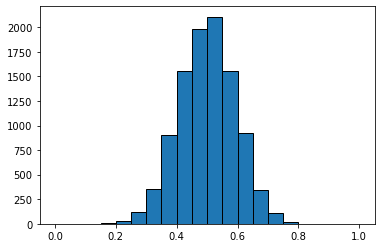

```python
k = 10000
n = 10
m = []
stddevs = []
df = pd.DataFrame()

bins = [0, 0.05,0.1,0.15,0.2,0.25,0.3,0.35,0.40,0.45,0.50,0.55,0.60,0.65,0.70,0.75,0.80,0.85,0.90,0.95,1]

for i in range(k):
    rand_lis =  [random.random_sample(1) for _ in range(n)]
    m.append(mean(rand_lis))
    stddevs.append(std(rand_lis))

df['M'] = m
df['Std.dev'] = stddevs

mean_mean = df['M'].mean()
print(f'n: {n}\nk: {k}')
print(f'Mean of the mean: {round(mean_mean,5)}')
sample_std_of_m = df['M'].std()
mean_of_std = df['Std.dev'].mean()
print(f'Mean of stddev: {round(mean_of_std,5)}\nStddev: {round(1 / sqrt(12),5)}\nSample std of m: {round(sample_std_of_m,7)}\nTrue sample std: {round(1 / sqrt(12 * n),7)}')
print('As we can observe the mean of the mean is much closer to the true mean (0.5) than in array M')

plt.hist(df['M'], bins=bins, edgecolor='k')
```

```
n: 10
k: 100000
Mean of the mean: 0.49994
Mean of stddev: 0.27026
Stddev: 0.28868
Sample std of m: 0.0912151
True sample std: 0.0912871
As we can observe the mean of the mean is much closer to the true mean (0.5) than in array M
```

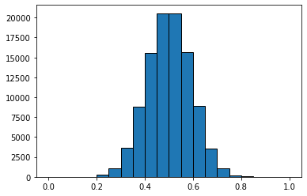

```python
k = 100000
n = 10
m = []
stddevs = []
df = pd.DataFrame()

bins = [0, 0.05,0.1,0.15,0.2,0.25,0.3,0.35,0.40,0.45,0.50,0.55,0.60,0.65,0.70,0.75,0.80,0.85,0.90,0.95,1]

for i in range(k):
    rand_lis =  [random.random_sample(1) for _ in range(n)]
    m.append(mean(rand_lis))
    stddevs.append(std(rand_lis))

df['M'] = m
df['Std.dev'] = stddevs

mean_mean = df['M'].mean()
print(f'n: {n}\nk: {k}')
print(f'Mean of the mean: {round(mean_mean,5)}')
sample_std_of_m = df['M'].std()
mean_of_std = df['Std.dev'].mean()
print(f'Mean of stddev: {round(mean_of_std,5)}\nStddev: {round(1 / sqrt(12),5)}\nSample std of m: {round(sample_std_of_m,7)}\nTrue sample std: {round(1 / sqrt(12 * n),7)}')
print('As we can observe the mean of the mean is much closer to the true mean (0.5) than in array M')

plt.hist(df['M'], bins=bins, edgecolor='k')
```

```python
k = 1000000
n = 10
m = []
stddevs = []
df = pd.DataFrame()

bins = [0, 0.05,0.1,0.15,0.2,0.25,0.3,0.35,0.40,0.45,0.50,0.55,0.60,0.65,0.70,0.75,0.80,0.85,0.90,0.95,1]

for i in range(k):
    rand_lis =  [random.random_sample(1) for _ in range(n)]
    m.append(mean(rand_lis))
    stddevs.append(std(rand_lis))

df['M'] = m
df['Std.dev'] = stddevs

mean_mean = df['M'].mean()
print(f'n: {n}\nk: {k}')
print(f'Mean of the mean: {round(mean_mean,5)}')
sample_std_of_m = df['M'].std()
mean_of_std = df['Std.dev'].mean()
print(f'Mean of stddev: {round(mean_of_std,5)}\nStddev: {round(1 / sqrt(12),5)}\nSample std of m: {round(sample_std_of_m,7)}\nTrue sample std: {round(1 / sqrt(12 * n),7)}')
print('As we can observe the mean of the mean is much closer to the true mean (0.5) than in array M')

plt.hist(df['M'], bins=bins, edgecolor='k')
```

[output not shown]

### Miniproject phase 3 (week 8)

1. See again the recent video on this subject (Week 7 / Lecture Package 2 / item 4).
2. Use the function rnorm(n,0,1) in R or NORM.INV(RAND(),0,1) in Excel to generate a vector of n=100,1000, ... random numbers with standard normal distribution N(0,1). Observe their histogram and how it evolves with increasing n.
3. Generate now several vectors of n random numbers with N(0,1), $z_1, z_2, z_3, ...$ and make histograms of $x_1=z_1^2$ , $x_2=z_1^2 + z_2^2 $, $x_3=z_1^2 + z_2^2 + z_3^2$ , .... What distribution you obtain? Compare with random numbers generated with the functions rchisq(n,k) or CHISQ.INV(RAND(),k).
4. Consolidate your understanding of the Chi square distribution by practicing such exercises. Make good graphical representations, optimise the number of bins, add on the graphs probability density functions for comparison. Calculate sample mean values using random numbers and compare with the true values. Observe median values. Imagine yourselves other experimental tests.

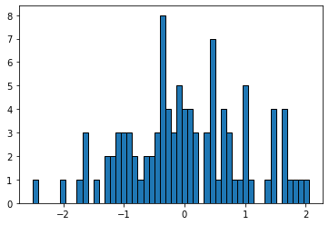

```python
import numpy as np
from scipy.stats import norm
import matplotlib.pyplot as plt

n = 100
lis = [np.random.normal() for _ in range(n)]
plt.hist(lis, bins=50, edgecolor='k')
```

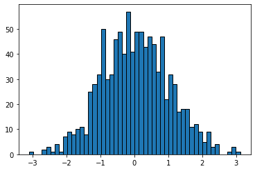

```python
import numpy as np
from scipy.stats import norm
import matplotlib.pyplot as plt

n = 1000
lis = [np.random.normal() for _ in range(n)]
plt.hist(lis, bins=50, edgecolor='k')
```

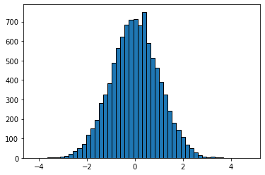

```python
import numpy as np
from scipy.stats import norm
import matplotlib.pyplot as plt

n = 10000
lis = [np.random.normal() for _ in range(n)]
plt.hist(lis, bins=50, edgecolor='k')
```

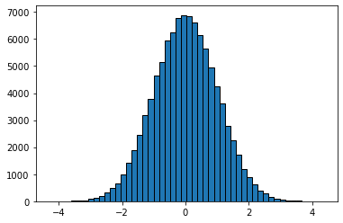

```python
import numpy as np
from scipy.stats import norm
import matplotlib.pyplot as plt

n = 100000
lis = [np.random.normal() for _ in range(n)]
plt.hist(lis, bins=50, edgecolor='k')
```

1. Generate now several vectors of n random numbers with N(0,1), $z_1, z_2, z_3, ...$ and make histograms of $x_1=z_1^2$ , $x_2=z_1^2 + z_2^2 $, $x_3=z_1^2 + z_2^2 + z_3^2$ , .... What distribution you obtain? Compare with random numbers generated with the functions rchisq(n,k) or CHISQ.INV(RAND(),k).
2. Consolidate your understanding of the Chi square distribution by practicing such exercises. Make good graphical representations, optimise the number of bins, add on the graphs probability density functions for comparison. Calculate sample mean values using random numbers and compare with the true values. Observe median values. Imagine yourselves other experimental tests.

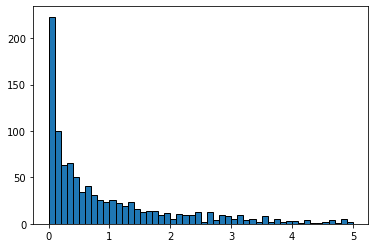

```python
import numpy as np
from scipy.stats import norm, chi2
import matplotlib.pyplot as plt

### chi square with DOF 1
n = 1000
z1 = np.array([np.random.normal() for _ in range(n)])

x = np.arange(0, 5, 0.005)

plt.hist(z1**2, bins=50, range=(0,5), edgecolor='k')
plt.show()
```

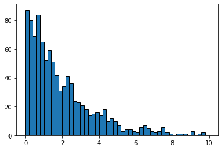

```python
import numpy as np
from scipy.stats import norm, chi2
import matplotlib.pyplot as plt

### chi square with DOF 1
n = 1000
z1 = np.array([np.random.normal() for _ in range(n)])
z2 = np.array([np.random.normal() for _ in range(n)])
z3 = np.array([np.random.normal() for _ in range(n)])
z4 = np.array([np.random.normal() for _ in range(n)])

### DOF = 2
zz = z1**2 + z2**2

plt.hist(zz, bins=50, range=(0,10), edgecolor='k')
```

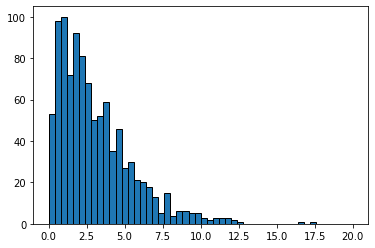

```python
import numpy as np
from scipy.stats import norm, chi2
import matplotlib.pyplot as plt

### chi square with DOF 1
n = 1000
z1 = np.array([np.random.normal() for _ in range(n)])
z2 = np.array([np.random.normal() for _ in range(n)])
z3 = np.array([np.random.normal() for _ in range(n)])
z4 = np.array([np.random.normal() for _ in range(n)])

### DOF = 2
zzz = z1**2 + z2**2 + z3**2

plt.hist(zzz, bins=50, range=(0,20), edgecolor='k')
```